# Movies Exploratory Data Analysis

## 3.6 tag

### 3.6.1 Number of tags

```r
cat("There are",unique_val(movies$tag), "tags for movies.")
```

```
## There are 64 tags for movies.
```

In order to use this variable for content-based modelling NLP techniques are required.

### 3.6.2 Missing values

```r
cat("There are", sum(is.na(movies$tag)), "missing values due to the new movies.")
```

[output not shown]

## 3.7 tagId

### 3.7.1 Number of genome tags

```r
cat("There are",unique_val(movies$tagId), "tag ids.")
```

```
## There are 1126 tag ids.
```

### 3.7.2 Missing values

```r
cat("We have",sum(is.na(movies$tagId)), "movies without any tag id. These were removed in the 00_DataCleaningDataJoin, when we decided to delete the tags with a relevance lower than 0.5.")
```

```
## We have 44960 movies without any tag id. These were removed in the 00_DataCleaningDataJoin, when we decided to delete the tags with a relevance lower than 0.5.
```

## 3.8 Rating

### 3.8.1 Rating distribution

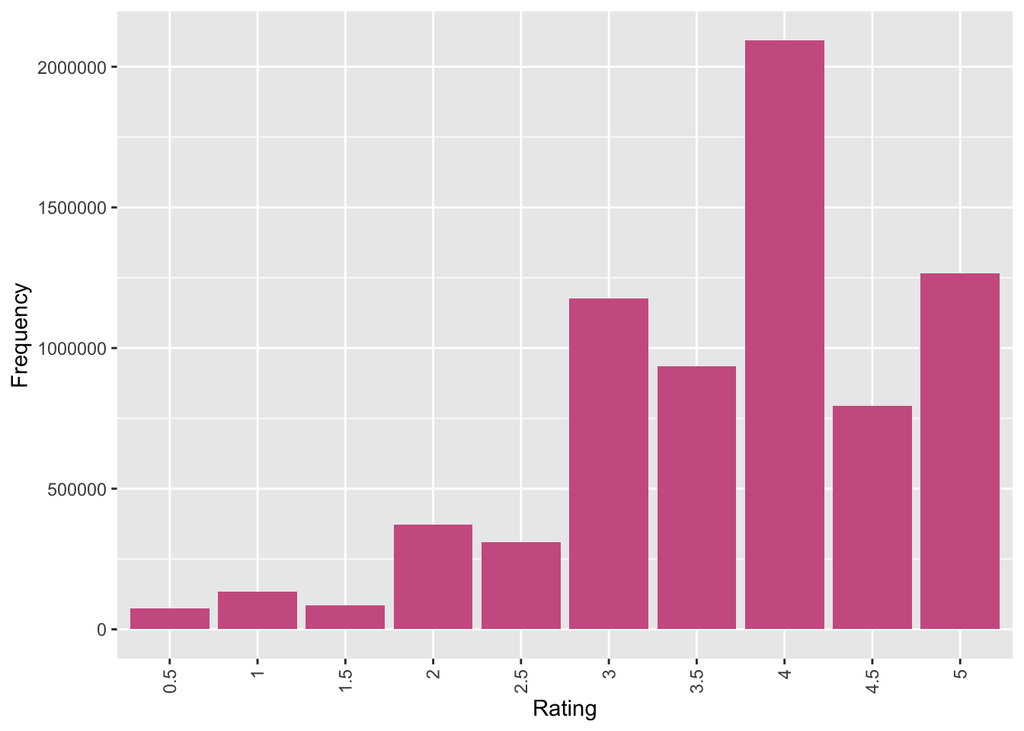

```r
ggplot(plot_input(movies$rating, "Rating"), aes(x=Rating, y=Freq)) + geom_bar(stat="identity",fill='hotpink3') + theme(axis.text.x = element_text(angle = 90, vjust = 0.5, hjust=1)) +labs(y= "Frequency", x = "Rating")
```

Ratings range from 0.5 to 5 with a 0.5 step size and they don’t follow any statistical distribution. Most movies are rated with a 4 out of 5.

### 3.8.2 Missing values

```r
cat("We have",sum(is.na(movies$rating)), "missing ratings, this could be due to the new movies and will be further analyzed.")
```

```
## We have 221453 missing ratings, this could be due to the new movies and will be further analyzed.
```

## 3.9 date_ratings & time_ratings

### 3.9.1 Date & time range

```r
oldest_rating <- summarise(movies, min(date_ratings, na.rm = TRUE))[1,1]
recent_rating <- summarise(movies, max(date_ratings, na.rm = TRUE))[1,1]
```

```r
cat("The oldest rating is from:", oldest_rating,"\n")
```

```
## The oldest rating is from: 1996-03-29
```

```r
cat("The most recent rating is from:", recent_rating)
```

```
## The most recent rating is from: 2018-09-24
```

### 3.9.2 Missing values

```r
cat("There are",sum(is.na(movies$date_ratings)), "missing dates and", sum(is.na(movies$time_ratings)), "missing times for our ratings which could mean that there are new movies that haven't been rated.")
```

```
## There are 221453 missing dates and 221453 missing times for our ratings which could mean that there are new movies that haven't been rated.
```

## 3.10 date_tags & time_tags

### 3.10.1 Date & time range

```r
oldest_tags <- summarise(movies, min(date_tags, na.rm = TRUE))[1,1]
recent_tags <- summarise(movies, max(date_tags, na.rm = TRUE))[1,1]
```

```r
cat("The oldest tag is from:", oldest_tags,"\n")
```

```
## The oldest tag is from: 2006-01-16
```

```r
cat("The most recent tag is from:", recent_tags)
```

```
## The most recent tag is from: 2018-08-05
```

### 3.10.2 Missing values

```r
cat("There are",sum(is.na(movies$date_tags)), "missing date tags and", sum(is.na(movies$time_tags)),"missing times for our tags this means that some movies haven't been watched.")
```

```
## There are 7452617 missing date tags and 7452617 missing times for our tags this means that some movies haven't been watched.
```

# 4. Conclusion

In conclusion, we should exclude from the training data set the new movies as they introduce a lot of NAs. When doing collaborative filtering we only need the ratings, the movieId and the userId. Maybe keeping the timestamp can also be useful to split the data (avoiding getting data from the future to predict the past).

Regarding content-based modelling, the data needs a lot of preprocessing and it is advised to use NLP and web scraping techniques to gather as much information as possible.